# Ekonometria - projekt

Natalia Głodek i Faustyna Bąk

# Przedstawienie zagadnienia, przedstawienie danych (opis, źródło danych)

Naszą pracę rozpoczęłyśmy od przygotowania bazy danych. W porozumieniu z firmą X weszłyśmy w posiadanie danych sprzedażowych za rok 2017 oraz 2018. Firma zajmuje się detaliczną oraz hurtową dystrybucją odzieży i tekstyliów w Polsce. Dostarczone dane zostały odpowiednio okrojone poprzez usunięcie rekordów z topowymi klientami. Zobowiązałyśmy się również, iż w związku z ustawą RODO, usuniemy wszystkie dane osobowe, pozwalające na identyfikację klientów firmy. Dlatego usunęłysmy kolumny przedstawiające szczegółowe dane adresowe i kontaktowe. Nazwy kontrahentów podmieniłyśmy na nazwiska olimpijczyków z zewnętrznej bazy danych. Dostarczone baza została wyeksportowana z systemu ERP firmy X i zapisana w postaci pliku csv.

Ponieważ nasze dane potrzebowały wielu transformacji, wykresy i statystyki znajdują sie w 2 części

# Transformacje wykonane na danych (np. usuwanie braków, usuwanie zmiennych, modyfikacja) oraz analiza (wykresy)

```r
# wczytywanie danych
sample <- read.csv('sample.csv', dec = ".", sep = ';')
produkt <- read.csv('produkt.csv', sep = ';')
```

Każdy wiersz w tabeli sample odpowiada za jedną operację z faktury. Są tam takie informacje jak nazwa klienta, adres zakupu,metoda płatności, data, kod produktu, jego cen oraz ilość.

```r
head(sample)
```

|  | Document.Type | Client.Number | Client.Name | Address.2 | Address.3 | Payment.Method | Document.number | Operation.Date | Year | Month | Item.Code | Item.Color | Item.Size | Supplier | Style | Item.Description | Quantity | Item.Price | Currency | Euro.Rate | Item.Value.in.Euro | Item.Type | Delivery.Method | Indicator | MEK.Item.Price | MEK.Purchase.Value | Purchase.Value.Curency |
| --- | --- | --- | --- | --- | --- | --- | --- | --- | --- | --- | --- | --- | --- | --- | --- | --- | --- | --- | --- | --- | --- | --- | --- | --- | --- | --- | --- |
| 1 | Invoice | 5053313 | David Kostelecký | 01-461 | Warszawa | 7 days | 2.017013e+13 | 20170102 | 2017 | January | 162851283 | 128 | 3 | 85 | 16285 | Jack Asphalt S | 0 | 22.43 | PLN | 4.3706 | 0.00 € | Product | UPS | 1.06 | 4.27 | 0 | EUR |
| 2 | Invoice | 5053313 | David Kostelecký | 01-461 | Warszawa | 7 days | 2.017013e+13 | 20170102 | 2017 | January | 162851284 | 128 | 4 | 85 | 16285 | Jack Asphalt M | 0 | 22.43 | PLN | 4.3706 | 0.00 € | Product | UPS | 1.06 | 4.27 | 0 | EUR |
| 3 | Invoice | 5053313 | David Kostelecký | 01-461 | Warszawa | 7 days | 2.017013e+13 | 20170102 | 2017 | January | 162851285 | 128 | 5 | 85 | 16285 | Jack Asphalt L | 0 | 22.43 | PLN | 4.3706 | 0.00 € | Product | UPS | 1.06 | 4.27 | 0 | EUR |
| 4 | Invoice | 5053313 | David Kostelecký | 01-461 | Warszawa | 7 days | 2.017013e+13 | 20170102 | 2017 | January | 162851286 | 128 | 6 | 85 | 16285 | Jack Asphalt XL | 0 | 22.43 | PLN | 4.3706 | 0.00 € | Product | UPS | 1.06 | 4.27 | 0 | EUR |
| 5 | Invoice | 5053313 | David Kostelecký | 01-461 | Warszawa | 7 days | 2.017013e+13 | 20170102 | 2017 | January | 162851287 | 128 | 7 | 85 | 16285 | Jack Asphalt 2XL | 0 | 22.43 | PLN | 4.3706 | 0.00 € | Product | UPS | 1.06 | 4.27 | 0 | EUR |
| 6 | Invoice | 5055048 | Mark Zabel | 02-674 | Warszawa | 7 days | 2.017013e+13 | 20170102 | 2017 | January | 212014104 | 410 | 4 | 1 | 21201 | 62-140-0 Orange M | 0 | 28.13 | PLN | 4.3706 | 0.00 € | Product | UPS | 1.06 | 5.53 | 0 | EUR |

W tabeli produkt znajdują się dokładne dane produktu. Każdy kod zawiera cenne informacje o kolorze, rozmiarze czy stylu.

```r
head(produkt)
```

|  | ItemCode | Item.Description | Style | ItemBrand | Brand | Brand.Group | Stock.Model | ItemCategory | Category | Item.Colour | Colour | ColourGroup | ColourIndex | Item.SubClass | Item.Class | Style.Colour | Style.Colour.Description | BoxQuantity | Intrastats.Codes | Item.Weight.in.KG | Country.of.Origin | Gender | Detailed.Category |
| --- | --- | --- | --- | --- | --- | --- | --- | --- | --- | --- | --- | --- | --- | --- | --- | --- | --- | --- | --- | --- | --- | --- | --- |
| 1 | 0 | 00 Russell Youngest Catalog DE | 0 | 0 | Russell Europe | IB | NO | 0 | Various | 0 | White | White | 1 | B4 | B | 0 | Unknown | 30 | 0 | 0.00 | Unknown | Unknown | Unknown |
| 2 | 3640000 | TO5503 White One Size | 364 | 64 | Jassz Towels | TBM | NO | 0 | Various | 0 | White | White | 1 | Unknown | Unknown | 364000 | TO5503 White | 40 | 63026000 | 0.29 | PK | Unknown | Towels |
| 3 | 3690000 | B44 White One Size | 369 | 69 | Beechfield | IB+ | NO | 0 | Various | 0 | White | White | 1 | Unknown | Unknown | 369000 | B44 White | 144 | 65050090 | 0.05 | CN | Unisex | Hats |
| 4 | 4640000 | TO5504 White One Size | 464 | 64 | Jassz Towels | TBM | NO | 0 | Various | 0 | White | White | 1 | Unknown | Unknown | 464000 | TO5504 White | 20 | 63026000 | 0.54 | PK | Unknown | Towels |
| 5 | 5170003 | TRS147 White S | 517 | 17 | Regatta | IB+ | NO | 0 | Various | 0 | White | White | 1 | Unknown | Unknown | 517000 | Unknown | 24 | 0 | 0.00 | Unknown | Unisex | Polo-Shirts |
| 6 | 5170004 | TRS147 White M | 517 | 17 | Regatta | IB+ | NO | 0 | Various | 0 | White | White | 1 | Unknown | Unknown | 517000 | Unknown | 24 | 0 | 0.00 | Unknown | Unisex | Polo-Shirts |

Z danych wybieramy elementy invoice, czyli faktury (w naszej nalizie nie będziemy brały pod uwagę zwrotów) oraz eliminujemy dane z fracht, gdyż jest to informacja o transporcie, która nie jest nam potrzebna.

```r
# wyfiltrowane dane bez fracht - transport i invoice, czyli dane z faktury, bez zwrotów
sample <- sample %>% filter(sample$Item.Type != "Fracht", sample$Document.Type == "Invoice")
```

Teraz wybieramy odpowiednie kolumny. Nie interesują nas takie dane jak np. numer klienta, jego dokładny adres, numer dokumentu czy opis produktu.

```r
# wybieram interesujące mnie kolumny
sample <- sample %>% select(Client.Name, Address.2, Payment.Method, Year, Month,Item.Code, Item.Color, Item.Size, Supplier, Quantity, Item.Price, Euro.Rate, Delivery.Method)

# zmieniam nazwy kolumn
colnames(sample) = c("Client.Name", "Postcode", "Payment.Method", "Year", "Month","Item.Code", "Item.Color", "Item.Size", "Supplier",
                      "Quantity", "Item.Price","Euro.Rate", "Delivery.Method")
```

Ponieważ jest to firma międzynrodowa ceny są zarówno w złotówkach jak i w euro, musimy doprowadzić do jednej waluty. Do tego przyda się kolumna euro rate, gdy cena jest w złotówkach eurorate = 4.3706, a gdy w euro eurorate = 1

```r
sample <- sample %>% mutate(price.in.euro = Item.Price * Euro.Rate)
```

Ponieważ jest bardzo dużo rożnych kolorów, pobieramy grupy kolorów z tabeli produkt (np czerwony zawiera w sobie jasny czerwony, burgundowy, bordowy, itp).

```r
produkt_color <- produkt %>% select(Item.Colour, ColourGroup)
produkt_color <- unique(produkt_color)
colnames(produkt_color) = c('Item.Color','ColourGroup')
sample <- sample %>% inner_join(produkt_color, by = 'Item.Color')
table(sample$ColourGroup)
```

```
##
##    Black     Blue    Brown Charcoal    Green     Grey  Natural     Navy
##   142063    26506     6608     5024    31646    57980     3904    54400
##   Orange     Pink   Purple      Red    Royal  Unknown    White   Yellow
##     9942    10427     4491    41870    29751       25    95484    12495
```

Jak widać mimo zawężenia kolorów jest ich nadal bardzo dużo. Zobaczmy, które z nich sprzedają się najlepiej.

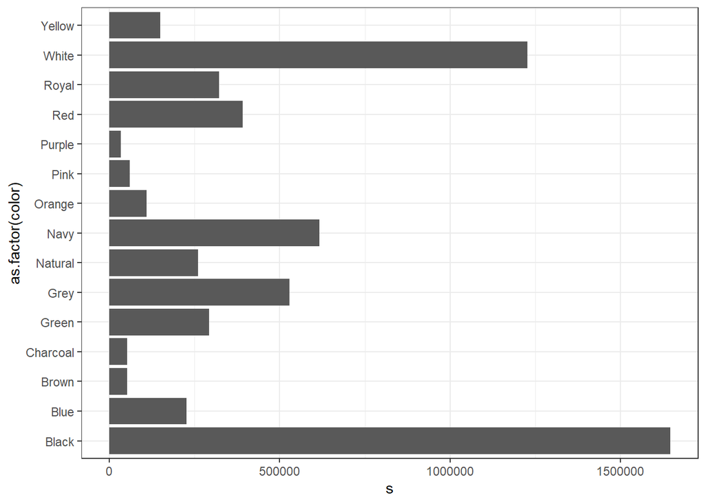

```r
kolor <- sample %>%
  group_by(color = ColourGroup) %>%
  summarize(s = sum(Quantity)) %>%
  filter(color != "Unknown") %>%
  arrange(desc(s))

kolor %>% ggplot(aes(y = as.factor(color),
                     x = s)) +
  geom_bar(stat = "identity",position="stack") +
  theme_bw()
```

Jak widać na wykresie najlepiej sprzedaje się kolor czarny i biały. Dlatego decydujemy się na jeszcze większe zawężenie kolorów i tworzymy klasy: biały, czarny i inny.

```r
sample <- sample %>% mutate(color = ifelse(ColourGroup == "White", "White", ifelse(ColourGroup == "Black", "Black", "other")))
```

Ponieważ supplier jest zapisane za pomocą cyfr i jest bardzo dużo grup, z tabeli produkt wybieramy kolumne brand group i łączymy ją z sample.

```r
produkt_brand <- produkt %>% select(ItemBrand, Brand.Group)
produkt_brand <- unique(produkt_brand)
colnames(produkt_brand) = c('Supplier', 'Brand.Group')
sample <- sample %>% inner_join(produkt_brand, by = 'Supplier')
```

Następnie z tabeli produkt wybieramy kolumne Category, jest to ważna informacja o stylu prodkuktu. Podobnie jak poprzedno łączymy dwie tabele za pomocą kolumny Item.Code

```r
produkt_style <- produkt %>% select(ItemCode, Category)
colnames(produkt_style) = c('Item.Code', 'Category')
produkt_style <- unique(produkt_style)
sample <- sample %>% inner_join(produkt_style, by = 'Item.Code')

table(produkt_style$Category)
```

```
##
##     Bags     Caps  Fleeces  Jackets    Polos   Shirts   Sweats T-Shirts
##     1059     1183     2732     3736     4653     2425     6803    15131
##  Various
##     5304
```

Przydatną daną może być również informacja o klientach.

```r
length(table(sample$Client.Name))
```

```
## [1] 2350
```

Ponieważ mamy zdecydowanie za dużo różnych klientów, pogrupujemy ich a następnie złączymy z tabelką sample

```r
klienci <- data.frame(Client.Name = sample$Client.Name, Quantity = sample$Quantity) %>% group_by(Client.Name) %>% summarize(sum = sum(Quantity))
klienci <- klienci %>%  mutate(Client.Category = ifelse(sum < 500, "small", ifelse(sum<1000, "medium", ifelse(sum<3000, "big", ifelse(sum<5000, "very.big", 'huge'))))) %>% select(-sum)

sample <- sample %>% inner_join(klienci, by = 'Client.Name')
```

Po przygotowaniu wszystkich kolumn, wybieramy odpowiednie i zmieniamy dane na dane kategoryczne.

```r
sample <- sample %>% select(-Client.Name, -Postcode, - Item.Code,-Item.Color,-Supplier, -Item.Price, -Euro.Rate, -ColourGroup) %>% mutate(Payment.Method = as.factor(Payment.Method),
                            Year = as.factor(Year),
                            Month = as.factor(Month),
                            Delivery.Method = as.factor(Delivery.Method),
                            color = as.factor(color),
                            Brand.Group = as.factor(Brand.Group),
                            Category = as.factor(Category),
                            Client.Category = as.factor(Client.Category)
                            )
```

# Dobór zmiennych

Aby odpowiednio dobrać zmienne najpier musimy je pogrupować. Postanowłyśmy pogrupować je na kilka różnych sposobów a następnie wybrać model z najlepszym $R^2$. W każdym przypadku będziemy usuwać po jednej zmiennej (od najmniej istotnych) aż $R^2$ Adjusted będzie największe. Ponieważ nasze dane są kategoryczne, w przypadku gdy np. miesiąc styczeń będzie nieistotny, ale miesiąc luty będzie istotny, to pozostawiamy wszystkie miesiące.

### sample 1

Najpierw grupujemy po wszystkich zmiennych, sumując quantity i biorąc średnią z price.

```r
sample_1 <- sample %>% group_by(Category,color, Month, Year, Client.Category, Brand.Group,  Delivery.Method) %>% summarize(Total.Quantity = sum(Quantity), avg_price_in_euro = mean(price.in.euro))
```

[output not shown]

```r
dummy_vars_1 <- model.matrix( ~ Category + color + Month + Year + Client.Category + Brand.Group + Delivery.Method, sample_1)

data_all_1 <- cbind(sample_1, dummy_vars_1)
data_all_1 <- data_all_1[,8:ncol(data_all_1)]
data_all_1 <- data_all_1[,-3]

model1a <- lm(Total.Quantity ~., data_all_1)
summary(model1a)
```

```
##
## Call:
## lm(formula = Total.Quantity ~ ., data = data_all_1)
##
## Residuals:
##    Min     1Q Median     3Q    Max
##  -3676   -841   -212    517  61074
##
## Coefficients:
##                            Estimate Std. Error t value Pr(>|t|)
## (Intercept)               1926.3792   145.3151  13.257  < 2e-16 ***
## avg_price_in_euro            0.8732     0.2808   3.109 0.001882 **
## CategoryCaps             -1115.0843   127.8082  -8.725  < 2e-16 ***
## CategoryFleeces          -1937.3182   137.2218 -14.118  < 2e-16 ***
## CategoryJackets          -1894.7494   153.8942 -12.312  < 2e-16 ***
## CategoryPolos            -1489.2486   115.5009 -12.894  < 2e-16 ***
## CategoryShirts           -1890.0632   145.2375 -13.014  < 2e-16 ***
## CategorySweats           -1485.4034   116.2209 -12.781  < 2e-16 ***
## `CategoryT-Shirts`         385.1536   103.2761   3.729 0.000193 ***
## CategoryVarious          -1460.8628   111.6098 -13.089  < 2e-16 ***
## colorother                 385.3638    58.0906   6.634 3.43e-11 ***
## colorWhite                -169.8707    66.3591  -2.560 0.010485 *
## MonthAugust                 11.5426   121.9482   0.095 0.924593
## MonthDecember             -189.8163   121.5686  -1.561 0.118461
## MonthFebruary             -242.5529   122.5375  -1.979 0.047795 *
## MonthJanuary              -250.9116   122.0514  -2.056 0.039827 *
## MonthJuly                   16.5928   121.7327   0.136 0.891582
## MonthJune                  277.8513   121.6961   2.283 0.022441 *
## MonthMarch                 -86.2588   120.9747  -0.713 0.475842
## MonthMay                   186.4138   121.2340   1.538 0.124167
## MonthNovember              -79.2779   119.5254  -0.663 0.507171
## MonthOctober               -68.7891   120.1693  -0.572 0.567040
## MonthSeptember             -15.5740   120.8489  -0.129 0.897462
## Year2018                    87.8467    49.8174   1.763 0.077866 .
## Client.Categoryhuge       1431.4238    73.7047  19.421  < 2e-16 ***
## Client.Categorymedium     -254.9337    81.7588  -3.118 0.001825 **
## Client.Categorysmall      -218.3191    78.9183  -2.766 0.005678 **
## Client.Categoryvery.big    -91.6736    80.1821  -1.143 0.252932
## `Brand.GroupIB+`          -937.3935    63.7031 -14.715  < 2e-16 ***
## Brand.GroupTBM           -1008.2343    68.0476 -14.817  < 2e-16 ***
## Delivery.MethodSpedition  -177.1505   181.2762  -0.977 0.328472
## Delivery.MethodUPS        -360.7024    54.7540  -6.588 4.68e-11 ***
## ---
## Signif. codes:  0 '***' 0.001 '**' 0.01 '*' 0.05 '.' 0.1 ' ' 1
##
## Residual standard error: 2576 on 10715 degrees of freedom
## Multiple R-squared:  0.1542, Adjusted R-squared:  0.1517
## F-statistic: 63.01 on 31 and 10715 DF,  p-value: < 2.2e-16
```

```r
model1b <- lm(Total.Quantity ~. -MonthAugust -MonthDecember -MonthFebruary -MonthJanuary
              -MonthJuly -MonthJune -MonthMarch -MonthMay -MonthNovember -MonthOctober -MonthSeptember  , data_all_1)
summary(model1b)
```

```
##
## Call:
## lm(formula = Total.Quantity ~ . - MonthAugust - MonthDecember -
##     MonthFebruary - MonthJanuary - MonthJuly - MonthJune - MonthMarch -
##     MonthMay - MonthNovember - MonthOctober - MonthSeptember,
##     data = data_all_1)
##
## Residuals:
##    Min     1Q Median     3Q    Max
##  -3445   -826   -220    527  61391
##
## Coefficients:
##                            Estimate Std. Error t value Pr(>|t|)
## (Intercept)               1887.7669   119.7235  15.768  < 2e-16 ***
## avg_price_in_euro            0.7664     0.2802   2.735 0.006246 **
## CategoryCaps             -1131.7058   127.8831  -8.850  < 2e-16 ***
## CategoryFleeces          -1923.3138   137.3221 -14.006  < 2e-16 ***
## CategoryJackets          -1863.3088   153.8823 -12.109  < 2e-16 ***
## CategoryPolos            -1472.0356   115.5712 -12.737  < 2e-16 ***
## CategoryShirts           -1865.9733   145.2937 -12.843  < 2e-16 ***
## CategorySweats           -1474.1663   116.3297 -12.672  < 2e-16 ***
## `CategoryT-Shirts`         386.8948   103.3729   3.743 0.000183 ***
## CategoryVarious          -1450.5230   111.7075 -12.985  < 2e-16 ***
## colorother                 388.0588    58.1531   6.673 2.63e-11 ***
## colorWhite                -167.4537    66.4306  -2.521 0.011726 *
## Year2018                    86.9697    49.8637   1.744 0.081162 .
## Client.Categoryhuge       1429.6770    73.7881  19.375  < 2e-16 ***
## Client.Categorymedium     -248.2733    81.8366  -3.034 0.002421 **
## Client.Categorysmall      -217.5236    79.0052  -2.753 0.005910 **
## Client.Categoryvery.big    -88.5006    80.2693  -1.103 0.270249
## `Brand.GroupIB+`          -923.0346    63.7166 -14.487  < 2e-16 ***
## Brand.GroupTBM           -1006.2852    68.1159 -14.773  < 2e-16 ***
## Delivery.MethodSpedition  -205.1436   181.1291  -1.133 0.257415
## Delivery.MethodUPS        -359.6901    54.8095  -6.563 5.53e-11 ***
## ---
## Signif. codes:  0 '***' 0.001 '**' 0.01 '*' 0.05 '.' 0.1 ' ' 1
##
## Residual standard error: 2579 on 10726 degrees of freedom
## Multiple R-squared:  0.1514, Adjusted R-squared:  0.1498
## F-statistic: 95.65 on 20 and 10726 DF,  p-value: < 2.2e-16
```

### sample 2

Grupujemy wybierając kolor, miesiac, kategorie i rok.

```r
sample_2 <- sample %>% group_by(Category,color, Month, Year) %>% summarize(Total.Quantity = sum(Quantity), avg_price_in_euro = mean(price.in.euro))
sample_2a <- data.frame(sapply(sample_2, unclass))


dummy_vars_2 <- model.matrix( ~ Category , sample_2)

data_all_2 <- cbind(sample_2a, dummy_vars_2)
data_all_2 <- data_all_2[,2:ncol(data_all_2)]
data_all_2 <- data_all_2[-6]


model2a <- lm(Total.Quantity ~ ., data_all_2)
summary(model2a)
```

```
##
## Call:
## lm(formula = Total.Quantity ~ ., data = data_all_2)
##
## Residuals:
##    Min     1Q Median     3Q    Max
## -30339  -1991   -439   1185  90359
##
## Coefficients:
##                      Estimate Std. Error t value Pr(>|t|)
## (Intercept)         15867.590   2032.530   7.807 2.43e-14 ***
## color               -1008.532    471.590  -2.139   0.0329 *
## Month                 185.305    108.898   1.702   0.0893 .
## Year                  789.673    752.443   1.049   0.2944
## avg_price_in_euro      -2.358      6.156  -0.383   0.7018
## CategoryCaps       -13066.127   1595.614  -8.189 1.45e-15 ***
## CategoryFleeces    -14799.064   1979.984  -7.474 2.58e-13 ***
## CategoryJackets    -14154.127   2715.566  -5.212 2.53e-07 ***
## CategoryPolos      -11761.040   1632.865  -7.203 1.68e-12 ***
## CategoryShirts     -15139.385   2022.968  -7.484 2.42e-13 ***
## CategorySweats     -11297.112   1728.008  -6.538 1.28e-10 ***
## `CategoryT-Shirts`  33571.004   1594.828  21.050  < 2e-16 ***
## CategoryVarious    -13418.713   1658.771  -8.090 3.05e-15 ***
## ---
## Signif. codes:  0 '***' 0.001 '**' 0.01 '*' 0.05 '.' 0.1 ' ' 1
##
## Residual standard error: 9569 on 635 degrees of freedom
## Multiple R-squared:  0.7162, Adjusted R-squared:  0.7108
## F-statistic: 133.5 on 12 and 635 DF,  p-value: < 2.2e-16
```

```r
#avg_price in euro ma małą istotność, więc wyrzucam ją i sprawdzam r^2
model2b <- lm(Total.Quantity ~ . -avg_price_in_euro, data_all_2)
summary(model2b)
```

```
##
## Call:
## lm(formula = Total.Quantity ~ . - avg_price_in_euro, data = data_all_2)
##
## Residuals:
##    Min     1Q Median     3Q    Max
## -30369  -2028   -387   1166  90357
##
## Coefficients:
##                    Estimate Std. Error t value Pr(>|t|)
## (Intercept)         15680.3     1971.5   7.953 8.32e-15 ***
## color                -969.4      460.1  -2.107   0.0355 *
## Month                 185.8      108.8   1.707   0.0883 .
## Year                  801.7      751.3   1.067   0.2863
## CategoryCaps       -13085.8     1593.7  -8.211 1.23e-15 ***
## CategoryFleeces    -15248.6     1593.7  -9.568  < 2e-16 ***
## CategoryJackets    -14996.2     1593.7  -9.410  < 2e-16 ***
## CategoryPolos      -11895.3     1593.7  -7.464 2.77e-13 ***
## CategoryShirts     -15616.2     1593.7  -9.799  < 2e-16 ***
## CategorySweats     -11552.0     1593.7  -7.248 1.23e-12 ***
## `CategoryT-Shirts`  33575.2     1593.7  21.067  < 2e-16 ***
## CategoryVarious    -13593.5     1593.7  -8.529  < 2e-16 ***
## ---
## Signif. codes:  0 '***' 0.001 '**' 0.01 '*' 0.05 '.' 0.1 ' ' 1
##
## Residual standard error: 9562 on 636 degrees of freedom
## Multiple R-squared:  0.7161, Adjusted R-squared:  0.7112
## F-statistic: 145.9 on 11 and 636 DF,  p-value: < 2.2e-16
```

```r
#bez tej zmiennej r^2 nieznacznie wzroslo

model2c <- lm(Total.Quantity ~ . -avg_price_in_euro - Year, data_all_2)
summary(model2c)
```

```
##
## Call:
## lm(formula = Total.Quantity ~ . - avg_price_in_euro - Year, data = data_all_2)
##
## Residuals:
##    Min     1Q Median     3Q    Max
## -30770  -2012   -410   1074  90758
##
## Coefficients:
##                    Estimate Std. Error t value Pr(>|t|)
## (Intercept)         16882.8     1617.9  10.435  < 2e-16 ***
## color                -969.4      460.1  -2.107   0.0355 *
## Month                 185.8      108.8   1.707   0.0883 .
## CategoryCaps       -13085.8     1593.9  -8.210 1.23e-15 ***
## CategoryFleeces    -15248.6     1593.9  -9.567  < 2e-16 ***
## CategoryJackets    -14996.2     1593.9  -9.409  < 2e-16 ***
## CategoryPolos      -11895.3     1593.9  -7.463 2.79e-13 ***
## CategoryShirts     -15616.2     1593.9  -9.798  < 2e-16 ***
## CategorySweats     -11552.0     1593.9  -7.248 1.23e-12 ***
## `CategoryT-Shirts`  33575.2     1593.9  21.065  < 2e-16 ***
## CategoryVarious    -13593.5     1593.9  -8.528  < 2e-16 ***
## ---
## Signif. codes:  0 '***' 0.001 '**' 0.01 '*' 0.05 '.' 0.1 ' ' 1
##
## Residual standard error: 9563 on 637 degrees of freedom
## Multiple R-squared:  0.7156, Adjusted R-squared:  0.7111
## F-statistic: 160.3 on 10 and 637 DF,  p-value: < 2.2e-16
```

```r
#bez tej zmiennej r^2 maleje
#wybieram model2b
```

### sample 3

Wybieramy Category, color, Month, Client.Category

```r
sample_3 <- sample %>% group_by(Category, color, Month, Client.Category) %>% summarize(Total.Quantity = sum(Quantity), avg_price_in_euro = mean(price.in.euro))
dummy_vars_3 <- model.matrix(~ Category + Month + color + Client.Category, sample_3)

data_all_3 <- cbind(sample_3, dummy_vars_3)
data_all_3 <- data_all_3[,5:ncol(data_all_3)]
data_all_3 <- data_all_3[,-3]

model3a <- lm(Total.Quantity ~ ., data_all_3)
summary(model3a)
```

```
##
## Call:
## lm(formula = Total.Quantity ~ ., data = data_all_3)
##
## Residuals:
##    Min     1Q Median     3Q    Max
## -17694  -4218    709   2911 167221
##
## Coefficients:
##                          Estimate Std. Error t value Pr(>|t|)
## (Intercept)              4086.604   1404.471   2.910  0.00367 **
## avg_price_in_euro           9.175      4.782   1.919  0.05520 .
## CategoryCaps            -5290.497   1146.199  -4.616 4.24e-06 ***
## CategoryFleeces         -8632.228   1558.978  -5.537 3.61e-08 ***
## CategoryJackets         -9873.975   2158.797  -4.574 5.17e-06 ***
## CategoryPolos           -5280.540   1177.614  -4.484 7.86e-06 ***
## CategoryShirts          -8159.008   1518.353  -5.374 8.90e-08 ***
## CategorySweats          -5661.748   1266.049  -4.472 8.31e-06 ***
## `CategoryT-Shirts`      13454.686   1145.916  11.741  < 2e-16 ***
## CategoryVarious         -6139.478   1202.677  -5.105 3.72e-07 ***
## MonthAugust               -65.330   1336.613  -0.049  0.96102
## MonthDecember           -1405.841   1335.481  -1.053  0.29265
## MonthFebruary           -1715.519   1340.744  -1.280  0.20090
## MonthJanuary            -1862.255   1343.913  -1.386  0.16604
## MonthJuly                 189.110   1334.108   0.142  0.88730
## MonthJune                1691.389   1336.310   1.266  0.20581
## MonthMarch               -540.097   1334.177  -0.405  0.68567
## MonthMay                 1112.087   1336.675   0.832  0.40555
## MonthNovember            -451.901   1339.566  -0.337  0.73590
## MonthOctober             -351.820   1331.974  -0.264  0.79171
## MonthSeptember           -159.082   1336.511  -0.119  0.90527
## colorother               2923.017    671.346   4.354 1.42e-05 ***
## colorWhite               -793.974    696.952  -1.139  0.25479
## Client.Categoryhuge     12055.080    860.621  14.007  < 2e-16 ***
## Client.Categorymedium   -1709.081    874.190  -1.955  0.05076 .
## Client.Categorysmall    -1716.288    868.772  -1.976  0.04838 *
## Client.Categoryvery.big  -733.341    866.562  -0.846  0.39754
## ---
## Signif. codes:  0 '***' 0.001 '**' 0.01 '*' 0.05 '.' 0.1 ' ' 1
##
## Residual standard error: 10860 on 1550 degrees of freedom
## Multiple R-squared:  0.3688, Adjusted R-squared:  0.3582
## F-statistic: 34.83 on 26 and 1550 DF,  p-value: < 2.2e-16
```

# Postać modelu

Po wielu kombinacjach i doborze zmiennych wybieramy model2b, czyli dane pogrupowane po Category,color, Month, Year a w modelu wybrane takie zmienne jak: Year, Category, color i Month, bez avg_price

```r
sample(data_all_2)
```

|  | CategoryVarious | CategorySweats | CategoryPolos | CategoryT-Shirts | CategoryShirts | CategoryFleeces | avg_price_in_euro | Total.Quantity | CategoryJackets | Month | CategoryCaps | color | Year |
| --- | --- | --- | --- | --- | --- | --- | --- | --- | --- | --- | --- | --- | --- |
| 1 | 0 | 0 | 0 | 0 | 0 | 0 | 56.29563 | 7640 | 0 | 1 | 0 | 1 | 1 |
| 2 | 0 | 0 | 0 | 0 | 0 | 0 | 43.87990 | 10422 | 0 | 1 | 0 | 1 | 2 |
| 3 | 0 | 0 | 0 | 0 | 0 | 0 | 43.98868 | 11916 | 0 | 2 | 0 | 1 | 1 |
| 4 | 0 | 0 | 0 | 0 | 0 | 0 | 55.85034 | 8745 | 0 | 2 | 0 | 1 | 2 |
| 5 | 0 | 0 | 0 | 0 | 0 | 0 | 47.91681 | 11548 | 0 | 3 | 0 | 1 | 1 |
| 6 | 0 | 0 | 0 | 0 | 0 | 0 | 70.70768 | 5328 | 0 | 3 | 0 | 1 | 2 |
| 7 | 0 | 0 | 0 | 0 | 0 | 0 | 53.17589 | 8903 | 0 | 4 | 0 | 1 | 1 |
| 8 | 0 | 0 | 0 | 0 | 0 | 0 | 54.45180 | 10309 | 0 | 4 | 0 | 1 | 2 |
| 9 | 0 | 0 | 0 | 0 | 0 | 0 | 60.79586 | 6657 | 0 | 5 | 0 | 1 | 1 |
| 10 | 0 | 0 | 0 | 0 | 0 | 0 | 53.90120 | 13005 | 0 | 5 | 0 | 1 | 2 |

[output cut: 638 more lines]

```r
summary(model2b)
```

```
##
## Call:
## lm(formula = Total.Quantity ~ . - avg_price_in_euro, data = data_all_2)
##
## Residuals:
##    Min     1Q Median     3Q    Max
## -30369  -2028   -387   1166  90357
##
## Coefficients:
##                    Estimate Std. Error t value Pr(>|t|)
## (Intercept)         15680.3     1971.5   7.953 8.32e-15 ***
## color                -969.4      460.1  -2.107   0.0355 *
## Month                 185.8      108.8   1.707   0.0883 .
## Year                  801.7      751.3   1.067   0.2863
## CategoryCaps       -13085.8     1593.7  -8.211 1.23e-15 ***
## CategoryFleeces    -15248.6     1593.7  -9.568  < 2e-16 ***
## CategoryJackets    -14996.2     1593.7  -9.410  < 2e-16 ***
## CategoryPolos      -11895.3     1593.7  -7.464 2.77e-13 ***
## CategoryShirts     -15616.2     1593.7  -9.799  < 2e-16 ***
## CategorySweats     -11552.0     1593.7  -7.248 1.23e-12 ***
## `CategoryT-Shirts`  33575.2     1593.7  21.067  < 2e-16 ***
## CategoryVarious    -13593.5     1593.7  -8.529  < 2e-16 ***
## ---
## Signif. codes:  0 '***' 0.001 '**' 0.01 '*' 0.05 '.' 0.1 ' ' 1
##
## Residual standard error: 9562 on 636 degrees of freedom
## Multiple R-squared:  0.7161, Adjusted R-squared:  0.7112
## F-statistic: 145.9 on 11 and 636 DF,  p-value: < 2.2e-16
```

```r
lm(model2b)
```

```
##
## Call:
## lm(formula = model2b)
##
## Coefficients:
##        (Intercept)               color               Month                Year
##            15680.3              -969.4               185.8               801.7
##       CategoryCaps     CategoryFleeces     CategoryJackets       CategoryPolos
##           -13085.8            -15248.6            -14996.2            -11895.3
##     CategoryShirts      CategorySweats  `CategoryT-Shirts`     CategoryVarious
##           -15616.2            -11552.0             33575.2            -13593.5
```

$Total.Quantity = 15680.3 -969.4 * color + 185.8 * Month + 801.7 * Year -13085.8 * CategoryCaps - 15248.6 * CategoryFleeces -14996.2 * CategoryJackets -11895.3 * CategoryPolos -15616.2 * CategoryShirts - 11552.0 * CategorySweats +33575.2 * CategoryT-Shirts -13593.5 * CategoryVarious$

# Diagnostyka modelu

Wszystkie testy będziemy robić przy poziomie istotności $\alpha = 0.05$

### Wartość oczekiwana reszt

Wartość oczekiwana reszt powinna być bliska zeru.

```r
mean(model2b$residuals)
```

```
## [1] -2.121811e-14
```

Wartość oczekiwana jest bliska 0

### Test Breusha Pagan’a

Teraz sprawdzimy czy składnik losowy jest homoskedastyczny, czyli czy ma jednorodne wariancje. Do tego użyjemy testu Breusha Pagan’a.

$H_0:$ Wariancje są jednorodne - występuje homoskedastyczność

$H_1:$ Wariancje nie są jednorodne - występuje heteroskedastyczność

```r
bptest(model2b)
```

```
##
##  studentized Breusch-Pagan test
##
## data:  model2b
## BP = 96.295, df = 11, p-value = 9.642e-16
```

Ponieważ p-value jest mniejsze od naszego poziomu istotności to odrzucamy $H_0$. Oznacza to, że w naszym modelu występuje heteroskedastyczność.

### Test na autokorelacje

Test Durbina-Watsona Wykrywanie autokorelacji

$H_0:$ p = 0

$h_1:$ p > 0

```r
dwtest(model2b)
```

```
##
##  Durbin-Watson test
##
## data:  model2b
## DW = 0.67559, p-value < 2.2e-16
## alternative hypothesis: true autocorrelation is greater than 0
```

Ponieważ p-value jest mniejsze od naszego poziomu istotności to odrzucamy $H_0$. Oznacza to, że w naszym modelu wystepuje autokorelacja

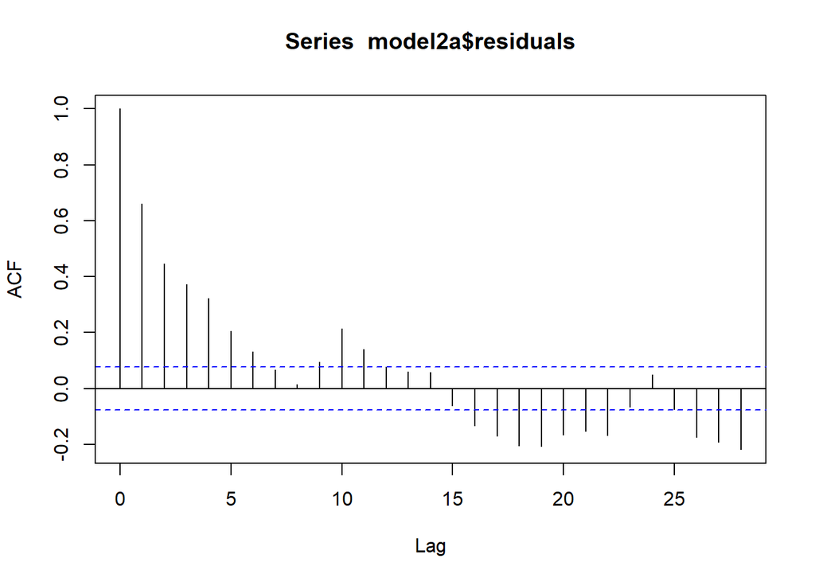

```r
acf(model2a$residuals, type = 'correlation')
```

### Istotność wszystkch parametrów

Stosujemy do tego uogólniony test walda

$H_0: \alpha_1 = ... = \alpha_k = 0$

$h_1:$ co najmniej jedna z $\alpha_j,j=k+1,..,k$ jest różna od zera

W R możemy zrobić test Walda lub zinterpretować statystykę F z summary(model2a)

```r
waldtest(model2b)
```

|  | Res.Df | Df | F | Pr(>F) |
| --- | --- | --- | --- | --- |
| 1 | 636 | NA | NA | NA |
| 2 | 647 | -11 | 145.8525 | 1.013834e-165 |

```r
summary(model2b)
```

```
##
## Call:
## lm(formula = Total.Quantity ~ . - avg_price_in_euro, data = data_all_2)
##
## Residuals:
##    Min     1Q Median     3Q    Max
## -30369  -2028   -387   1166  90357
##
## Coefficients:
##                    Estimate Std. Error t value Pr(>|t|)
## (Intercept)         15680.3     1971.5   7.953 8.32e-15 ***
## color                -969.4      460.1  -2.107   0.0355 *
## Month                 185.8      108.8   1.707   0.0883 .
## Year                  801.7      751.3   1.067   0.2863
## CategoryCaps       -13085.8     1593.7  -8.211 1.23e-15 ***
## CategoryFleeces    -15248.6     1593.7  -9.568  < 2e-16 ***
## CategoryJackets    -14996.2     1593.7  -9.410  < 2e-16 ***
## CategoryPolos      -11895.3     1593.7  -7.464 2.77e-13 ***
## CategoryShirts     -15616.2     1593.7  -9.799  < 2e-16 ***
## CategorySweats     -11552.0     1593.7  -7.248 1.23e-12 ***
## `CategoryT-Shirts`  33575.2     1593.7  21.067  < 2e-16 ***
## CategoryVarious    -13593.5     1593.7  -8.529  < 2e-16 ***
## ---
## Signif. codes:  0 '***' 0.001 '**' 0.01 '*' 0.05 '.' 0.1 ' ' 1
##
## Residual standard error: 9562 on 636 degrees of freedom
## Multiple R-squared:  0.7161, Adjusted R-squared:  0.7112
## F-statistic: 145.9 on 11 and 636 DF,  p-value: < 2.2e-16
```

Ponieważ p-value jest mniejsze od 0.05 odrzucamy hipotezę zerową na rzecz hipotezy alternatywnej. Na tym poziomie istotności można powiedzieć, że minimum jeden parametr jest istotny.

### Normalność reszt

$H_0$ reszty mają rozkład normalny $H_1$ reszty nie mają rozkładu normalnego

```r
shapiro.test(model2a$residuals)
```

```
##
##  Shapiro-Wilk normality test
##
## data:  model2a$residuals
## W = 0.63941, p-value < 2.2e-16
```

Odrzucamy $H_0$ a więc reszty nie mają rozkładu normalnego.

### Test RESET

Sprawdzmy czy model ma dobrze dobraną postać

$H_0$ wybór postaci analitycznej modelu jest prawidłowy

$H_1$ wybór postaci analitycznej modelu nie jest prawidłowy

```r
resettest(model2a)
```

```
##
##  RESET test
##
## data:  model2a
## RESET = 5.5108, df1 = 2, df2 = 633, p-value = 0.004239
```

Z testu wynika, że dobór postaci modelu nie jest prawidłowy.

# Próba poprawy modelu

Ponieważ w naszym modelu występuje autokorelacja i heteroskedastyczność a test RESET pokazał, że mamy złą postać modelu to musimy zmodyfikować model2a.

Próba usunięcia autokorelacji

```r
model2b_pop <- lm(Total.Quantity ~ CategoryCaps + CategoryFleeces + CategoryJackets + CategoryPolos + CategoryShirts + CategorySweats + `CategoryT-Shirts` + CategoryVarious + color + Month + Year/sqrt(Year), data_all_2)

dwtest(model2b_pop)
```

[output not shown]

Próba usunięcia heteroskedastyczności - użycie ważonej metody najmniejszych kwadratów

```r
wt <- 1 / lm (abs(model2b$residuals)~model2b$fitted.values)$fitted.values^2
wls_model2b <- lm(Total.Quantity ~ CategoryCaps + CategoryFleeces + CategoryJackets + CategoryPolos + CategoryShirts + CategorySweats + `CategoryT-Shirts` + CategoryVarious + color + Month + Year, data_all_2, weights = wt)

bptest(wls_model2b)
```

```
##
##  studentized Breusch-Pagan test
##
## data:  wls_model2b
## BP = 4.9053e-07, df = 11, p-value = 1
```

```r
bgtest(wls_model2b)
```

```
##
##  Breusch-Godfrey test for serial correlation of order up to 1
##
## data:  wls_model2b
## LM test = 283.89, df = 1, p-value < 2.2e-16
```

```r
summary(wls_model2b)
```

```
##
## Call:
## lm(formula = Total.Quantity ~ CategoryCaps + CategoryFleeces +
##     CategoryJackets + CategoryPolos + CategoryShirts + CategorySweats +
##     `CategoryT-Shirts` + CategoryVarious + color + Month + Year,
##     data = data_all_2, weights = wt)
##
## Weighted Residuals:
##     Min      1Q  Median      3Q     Max
## -2.1171 -0.6776 -0.3019  0.4637  6.2827
##
## Coefficients:
##                     Estimate Std. Error t value Pr(>|t|)
## (Intercept)         16242.20     989.88  16.408  < 2e-16 ***
## CategoryCaps       -12984.15     963.40 -13.477  < 2e-16 ***
## CategoryFleeces    -14774.20     937.08 -15.766  < 2e-16 ***
## CategoryJackets    -14467.13     939.54 -15.398  < 2e-16 ***
## CategoryPolos      -11375.72     982.47 -11.579  < 2e-16 ***
## CategoryShirts     -14784.54     933.87 -15.831  < 2e-16 ***
## CategorySweats     -11503.14     988.53 -11.637  < 2e-16 ***
## `CategoryT-Shirts`  33967.69    2701.25  12.575  < 2e-16 ***
## CategoryVarious    -13205.33     956.21 -13.810  < 2e-16 ***
## color                -575.44     103.03  -5.585 3.46e-08 ***
## Month                  29.25      23.59   1.240   0.2154
## Year                  282.43     163.11   1.732   0.0838 .
## ---
## Signif. codes:  0 '***' 0.001 '**' 0.01 '*' 0.05 '.' 0.1 ' ' 1
##
## Residual standard error: 1.13 on 636 degrees of freedom
## Multiple R-squared:  0.5708, Adjusted R-squared:  0.5634
## F-statistic: 76.89 on 11 and 636 DF,  p-value: < 2.2e-16
```

Udało się usunąć heteroskedastyczność, jednak $R^2$ znacznie zmalało i pojawiła się autokorelacja. Dlatego będziemy używać modelu - model2b_pop z heteroskedastycznością.

# Podział na zbiór treningowy i testowy

```r
split <- sample.split(data_all_2$color, SplitRatio = 0.8)

train <- subset(data_all_2, split == TRUE)
test <- subset(data_all_2, split == FALSE)
```

# Prognoza na zbiór testowy i błędy prognozy

Tworzę model dla zbiory treningowego

```r
model2b_pop_train <- lm(Total.Quantity ~ CategoryCaps + CategoryFleeces + CategoryJackets + CategoryPolos + CategoryShirts + CategorySweats + `CategoryT-Shirts` + CategoryVarious + color + Month + Year/sqrt(Year), train)
summary(model2b_pop_train)
```

```
##
## Call:
## lm(formula = Total.Quantity ~ CategoryCaps + CategoryFleeces +
##     CategoryJackets + CategoryPolos + CategoryShirts + CategorySweats +
##     `CategoryT-Shirts` + CategoryVarious + color + Month + Year/sqrt(Year),
##     data = train)
##
## Residuals:
##    Min     1Q Median     3Q    Max
## -31463  -2100   -413   1238  89379
##
## Coefficients: (1 not defined because of singularities)
##                    Estimate Std. Error t value Pr(>|t|)
## (Intercept)         14934.2     2364.7   6.315 5.89e-10 ***
## CategoryCaps       -12623.8     1878.5  -6.720 4.90e-11 ***
## CategoryFleeces    -14721.0     1936.0  -7.604 1.40e-13 ***
## CategoryJackets    -14233.9     1936.8  -7.349 8.05e-13 ***
## CategoryPolos      -11428.2     1893.7  -6.035 3.07e-09 ***
## CategoryShirts     -15127.9     1885.8  -8.022 7.27e-15 ***
## CategorySweats     -10739.9     1886.1  -5.694 2.10e-08 ***
## `CategoryT-Shirts`  35149.7     1887.4  18.623  < 2e-16 ***
## CategoryVarious    -13071.4     1917.8  -6.816 2.67e-11 ***
## color                -919.7      543.9  -1.691   0.0915 .
## Month                 247.0      127.9   1.932   0.0540 .
## Year                  612.9      887.8   0.690   0.4903
## Year:sqrt(Year)          NA         NA      NA       NA
## ---
## Signif. codes:  0 '***' 0.001 '**' 0.01 '*' 0.05 '.' 0.1 ' ' 1
##
## Residual standard error: 10100 on 507 degrees of freedom
## Multiple R-squared:  0.7078, Adjusted R-squared:  0.7015
## F-statistic: 111.6 on 11 and 507 DF,  p-value: < 2.2e-16
```

Tworzę predykcję dla zbioru testowego

```r
prediction <- predict(model2b_pop_train, test, se.fit = TRUE)
```

Wyliczam błedy ex-post

```r
ex_post <- test$Total.Quantity - prediction$fit  #bledy prognoz
(MAE <- mean(abs(ex_post)))  #mean absolute error - o ile srednio bledy sie odchylaly
```

```
## [1] 4026.207
```

```r
(RMSE <- mean(sqrt((ex_post)^2)))  #Root Mean Squared error
```

```
## [1] 4026.207
```

```r
(MAPE <- mean(abs((test$Total.Quantity - prediction$fit))/test$Total.Quantity)) #Mean Absolute Percentage Error
```

```
## [1] 4.601979
```

```r
id <- c(1:129)
test <-cbind(test, id = id)
```

Wykres przedstawiający błędy prognozy

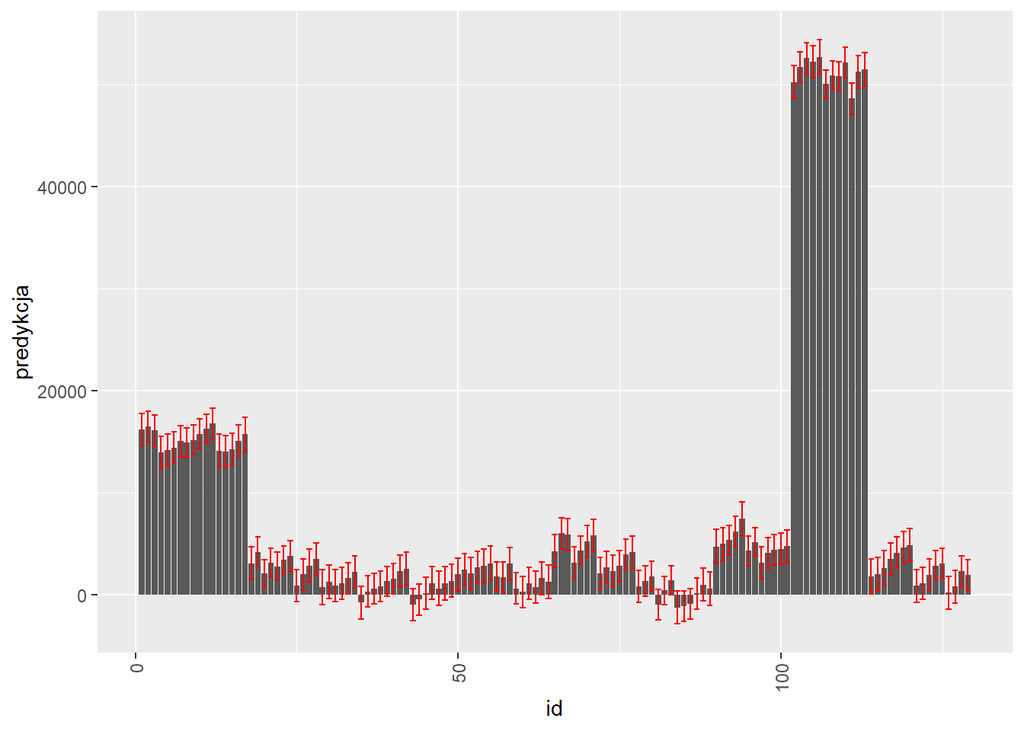

```r
predykcja_blad <- data.frame( id = test$id, predykcja = prediction$fit, SE = prediction$se.fit)
predykcja_blad %>% ggplot(aes(x = id, y = predykcja )) +
  geom_col() +
  theme(axis.text.x = element_text(angle = 90, vjust = 0.5, hjust=1)) +
  geom_errorbar(aes(ymin = predykcja - SE, ymax = predykcja + SE), color = "red")
```

# Podsumowanie (w tym interpretacja)

Bardzo przepraszamy za opóźnienie w przesłaniu projektu, błędnie zrozumiałyśmy datę przesłania na upelu.